# Kapitel 13 De basala ganglierna

De basala ganglierna (**Fig 13.3**) ligger djupt under hjärnbarkens främre del. De finreglerar motoriken och är inblandade i planering av målstyrt beteende, inlärning och vanemässiga beteenden. Inflödet av signaler kommer främst från hjärnbarken och efter bearbetning signalerar de basala ganglierna tillbaks dit via thalamus. På så vis reglerar de basala ganglierna avpassningen i tid (timing-) och graden av aktivitet för de signaler som går från hjärnbarken till pyramidbanorna, bland annat med följden att beteenden som leder till belöning stimuleras och beteenden som leder till negativa resultat hämmas. Utflödande signaler från basala ganglierna till talamus är förknippat med utförande av en rörelse, emedan upphörd signalering från basala ganglierna är förknippat med pausning av rörelsen. Paralella system inom de basala ganglierna med liknande uppbyggnad finns för motorik, ögonrörelser, exekutiva funktioner och emotioner.

Delar av de basala ganglierna (nucleus accumbens, ventral pallidum, and ventral tegmental area) ingår i det *limbiska systemet* och är av särskild betydelse för belöningsrelaterad inlärning. Den mesolimbiska banan som löper från VTA till nucleus accumbens är viktig i detta sammanhang. De basala gangliernas roll vid drogberoende diskuteras i stycke 3.4.

De basala ganglierna utövar sin effekt på impulser från hjärnbarken via talamus, som står under kontinuerlig hämning (GABA) från de basala gangliernas sk “output”-kärnor (utflödeskärnor, SNr, GPi). När aktiviteten i dessa utflödeskärnor ökas innebär det en starkare hämning av talamus och det motsatta sker vid minskad aktivitet.

## 13.1 Striatum

Striatum får glutamaterga signaler från hela cortex (ipsilateralt och kontralateralt) samt från thalamus. De flesta av neuronerna i striatum är så kallade “Medium spiny neurons” (MSNs). Dessa uttrycker förutom glutamatreceptorer även dopaminreceptorer av D1-typ och/eller D2-typ. Hos 40% (en del senare studier visar dock < 6% i dosala striatum) av MSN i striatum finns båda dessa receptortyper. Dopamin *stimulerar* D1-MSN och *hämmar* aktiviteten i D2-MSN. Både D1-MSN och D2-MSN har även receptorer för andra signalsubstanser, tex acetylcholin. MSN-axonerna frisätter i sin tur GABA, vilket har en inhibitorisk effekt på målet. Den sk direkta banan från *ventrala* striatum domineras av D1-MSN och är kopplat till belöning emedan den indirekta banan domineras av D2-MSN och är kopplad till aversion. De direkta och indirekta banorna i *dorsala* striatum är istället förbundna med motoriska funktioner.

Striatum får glutamaterga signaler från amygdala och serotoninerga från Raphe Nuclei. Sådana serotinonerga banor kan ligga bakom levodopa-inducerade dyskinesier.

## 13.2 Den direkta och indirekta banan

Signalerna från striatum till utflödeskärnan GPi kan förenklat beskrivas med två olika banor (**Fig 13.2**).

Den “direkta banan” går direkt från striatum till GPi och består i huvudsak av axoner från D1-MSN, vilka stimuleras av dopamin och har en hämmande (GABAerg) effekt på GPi. Aktivering av den direkta banan ger således ökad thalamusaktivitet.

Den “indirekta banan” går från striatum till GPi med GPe och subtalamuskärnan som mellansteg. Neuronerna från striatum till GPe är (toniskt?) inhibitoriska, liksom neuronerna från GPe till subtalamuskärnan. Denna sänder i sin tur excitatoriska signaler till GPi. Eftersom neuronerna från striatum i denna bana är i huvudsak D2-MSN *hämmas* de av dopamin, vilket leder till att hämningen av GPe släpper, varvid denna kärna förstärker sin hämning av subtalamuskärnan, med följden att GPi får minde stimuli. Sluteffekten av en hämning i den första delen av den indirekta banan (Striatum-GPi) blir ökad thalamusaktivitet. Senare forskning har visat att celler med D1 receptorer även ingår i den indirekta banan och att celler med D2-receptorer ingår i den direkta banan.

Direkta banan - belöning, indirekta banan aversion?

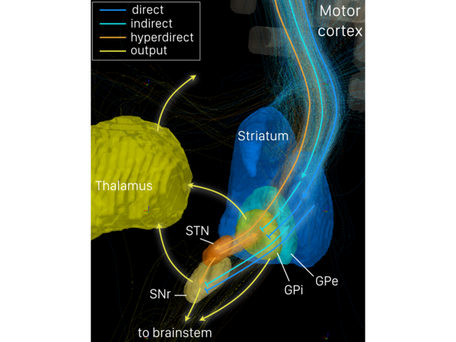

Figur 13.1: Indirect, direct and hyperdirect pathway.

Note: Bilden stämmer inte riktigt med nedan. Kolla upp!

Cortex —–> Striatum ——————-GABA———————–| - GPi  
-—GABA—–| GPe —-GABA—-| Subthalamus —-> + GPi

## 13.3 Pallidum

Nervcellerna i *pallidum* (globus pallidus och ventrala pallidum) utsänder hämmande signaler (GABA) till sina mål, så länge de inte får signaler från striatum. Signaler från striatum till pallidum gör att aktiviteten hos nervcellerna där minskar och därmed släpper hämningen av målstrukturerna som då ökar sin aktivitet (desinhiberas).

Pallidum består av *ventrala pallidum*, *globus pallidus interna* och *globus pallidus externa*. GPe och GPi består av liknande celltyper (stora, GABAerga neuroner) och kommunicerar med varandra.

## 13.4 Substantia nigra och globus pallidus interna

Den svarta substansen (lat. *substantia nigra*) indelas i pars compacta (SNc) och pars reticulata (SNr). SNr kommunicerar med GPi och inhiberer *thalamus* genom att frisätta GABA. SNc å andra sidan producerar dopamin och reglerar aktiviteten i *striatum*.

SNr tillsammans med GPi benämns ibland “output nuclei”. Båda består av inhibitoriska GABAerga nervceller som avger tonisk, hämmande aktivitet till thalamus. SNr och GPi hämmas av D1-MSN belägna i striatum via den direkta banan. De stimuleras av subtalamuskärnans glutamaterga projektioner som löper i senare delen av den indirekta banan. När den första delen av den indirekta banan (D2-MSN i striatum) hämmas av dopamin leder det också till minskad aktivitet i GPi.

## 13.5 Globus pallidus externa

GPe har GABAerga nerveller och erhåller hämmande GABA-signaler från D2-MSN i striatum. Excitatoriska glutamat-signaler kommer till GPe från subthalamuskärnan.

## 13.6 Subthalamuskärnan

Nervcellerna här producerar glutamat och har därmed en stimulerande effekt. Kärnan får hämmande signaler från GPe och skickar excitatoriska signaler till GPe, GPi, SNr och delar av talamus. Kärnan är del av den *indirekta banan*. Den får även glutamaterga signaler direkt från cortex via den *hyperdirekta banan*, som därmed förbipasserar basala gangliernas “input nuclei” och medför snabbare konduktionstid med starkt inflytande över basala gangliernas utflöde. Subthalamuskärnan kan delas in i en motorisk, associativ respektive limbisk region.

I subthalamuskärnan sätts elektroder vid “deep brain stimulation”.

## 13.7 Signalsubstanser i de basala ganglierna

Dopaminerga nervceller i SNc innehåller neuromelanin, en prekursor till dopamin, som ger området dess svarta färg. Dessa nervceller förstörs gradvis vid Parkinsons sjukdom. Överlevande nervceller innehåller aggregat av felveckade proteiner vilka ses histologiskt som sk Lewy-kroppar.

Från ventrala tegumentet, SNc och retrorubrala området kommer dopaminergt inflöde till basala ganglierna. Ventrala tegumentet förser främst nucleus accumbens och områden i limbiska systemet, medan SNc och retrrubrala området främst utgör den nigrostriatala banan.

## 13.8 Basala gangliernas funktion

I den klassika modellen beskrivs striato-pallidala kopplingen via direkta och indirekta banan, vilka med sin grundaktivitet har motsatta effekter på utflödet från de basala ganglierna (**Fig 13.2**). Via direkta banan inhiberas det toniska aktiviteten i GPi/SNr. Indirekta banan inhiberar GPe och desihiberar därmed subthalamuskärnan, vilken ökar den toniska aktiviteten i GPi/SNr. Den klassiska modellen har ifrågasatts, men fått stöd av senare forskning. Den klassiska modellen har modifierats och man har nu beskrivit re-entry kretsar inom de basala ganglierna och att detta nätverk kan gynna eller hämma samtidiga signaler snarare än hantera en signal åt gången.

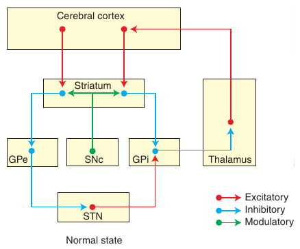

Figur 13.2: Original basal ganglia model.

Brist på dopamin medför ökad inhibitorisk aktivitet i förstaneuronen i den indirekta banan, vilka löper från striatum till GPe, vars inhibition av subthalamuskärnan då i sin tur minskar. Subthalamuskärnan ökar då sina glutamaterga signaler vilket ger överaktivering av inhibitoriska neuroner i GPi/SNr. Samtleder dopaminbristen till minskad inhibitorisk aktivitet i den direkta banan vilket bidrar till överaktivering av GPi/SNr. Denna överaktivitet försvårar pausning av det hämmande utflödet från GPi till thalamus och begränsar därför igångsättning och utförande av rörelser. Dyskinesi (hemichorea-ballism, levodopainducerade dyskinesier) kan med denna modell förstås som en reduktion i utflöde från GPi, dvs motsatsen till parkinsonism.

De basala ganglierna kan delas in efter funktioner, beroende på deras relation till olika områden i hjärbarken: Motorisk, associativ och emotionell/limbisk funktion. Dessa är förknippade med aktivitet i olika delar av striatum, med motoriska funktioner posteriort, emotionella funktioner ventralt.

Tidsuppfattning, implicit lärande, vanebildning, belöningsrelaterat beteende, emotioner är exempel på funktioner som går via striatum.

Artificiell blockering av olika delar av de basala ganglierna ger dyskinesier, stereotypier, hyperaktivitet, tics-liknande beteende, sexuellt beteende (erektion, ejakulation), kräkning med mera.

## 13.9 Nigrostriatala banan

Nigrostriatala banan går från substantia nigra (SNc) och utgör huvuddelen av det dopaminerga inflödet till striatum. Dopamin stimulerar D1-MSN och hämmar D2-MSN, vilket leder till ökad aktivitet i den direkta banan och samtidigt minskad aktivitet i den indirekta banans förstaneuron.

## 13.10 Mesostriatala banan

Vantrala tegumentet

## 13.12 Lista över de basala ganglierna och relaterade kärnor

The term basal ganglia in the strictest sense refers to nuclei embedded deep in the brain hemispheres (striatum or caudate-putamen and globus pallidus), whereas related nuclei consist of structures located in the diencephalon (subthalamic nucleus), mesencephalon (substantia nigra), and pons (pedunculopontine nucleus).

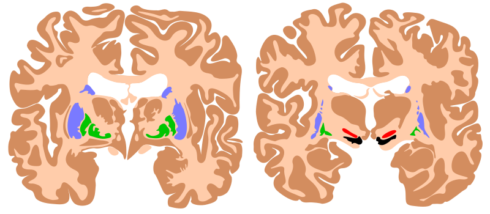

Figur 13.3: Koronalt snitt genom de basala ganglierna.

1. Dorsala striatum (nuleus lenticulare) 1.1 Nucleus caudatus (CN, sv. *svanskärnan*) 1.2 Putamen (Put, sv *yttre skalkärnan*) 1.3 Globus pallidus 1.3.1 Internal (medial) segment (GPi) 1.3.2 External (lateral) segment (GPe)
2. Ventrala striatum 1.1 Nucleus accumbens (Acb, sv. *accumbenskärnan*) 1.1 Olfactory tubercle
3. Ventrala pallidum
4. Substantia nigra(a) 4.1 Pars compacta (SNc) 4.2 Pars reticulata (SNr)
5. Subthalamic nucleus(a) (STN, sv. *subtalamuskärnan*)
6. Pedunculopontine nucleus(a)

Amygdala?

1. Ingår ej i snäv mening i de basala ganglierna (som ligger i hjärnhalvorna), eftersom de ligger i mesencephalon, diencephalon respektive pons.

Functional Neuroanatomy of the Basal Ganglia lanciego[160] ger en översikt.

### 13.12.1 Lista över nervbanor

[figure not shown]

Figur 13.4: Mesolimbiska banan.

### 13.12.2 Funktioner relaterade till de basala ganglierna

Motorik Motorisk inlärning Exekutiva funktioner och beteenden Emotioner

### 13.12.3 Sjukdomar och symtom vid störd funktion i basala ganglierna

Historiskt (och ibland fortfarande) används begreppet “extrapyramidala syndrom” för att beskriva störningar i de basala ganglierna, men detta begrepp anses förlegat och bör inte längre användas[160].

- Movement disorders
  - Parkinsons sjukdom
  - Huntingtons sjukdom
- Tourette syndrome
- Hemiballismus
- Obsessive–compulsive disorder
- Dystonia
- Addiction
- Tics
- Chorea

#### 13.12.3.1 Parkinsonism

Karaktäriseras av rigiditet (ökad muskeltonus i vila), hypokinesi (få spontana rörelser)/akinesi, bradykinesi och vilotremor.

Dopaminbrist gör att den indirekta vägen dominerar vilket leder till att basala gangliernas inhbition av thalamus svårligen kan brytas för att sätta igång rörelser. De basala ganglierna reagerar vid parkinsons sjukdom även annorlunda på stimuli utifrån. Putamen, subtalamuskärnan och GPi har en ökad reaktivitet vilket försvårar filtreringen av impulser. Effekten av detta blir att rörelser utgående från hjärnbarken hämmas, vilket kan förklara hypokinesi och bradykinesi, men hur sjukdom i basala ganglierna orsakar rigiditet och tremor är inte känt.

#### 13.12.3.2 Dystoni

Långvarig muskelspasm och onormal kroppsställning.

#### 13.12.3.3 Dyskinesi (chorea eller ballism)

Chorea är fragmenterade rörelser som flödar från en kroppsdel till en annan. Vid stor amplitud på rörelserna läggs “ballism” till beskrivningen. Den vanligaste orsaken till dyskinesi är levodopabehandling till parkinsonpatienter. Andra orsaker är Huntingtons sjukdom, hyperthyreos och systemisk lupus erythematosus.

Minskad aktivitet i subthalamuskärnans bana till GPi med minskad aktivitet från GPi är en förklaringsmodell för dessa symtom.

Chorea kan uppstå efter skador i basala ganglierna, tex subthalamuskärnan.

Blockering av den hämmande banan från striatum till GPe (vilket leder till desinhibering av GPe med efterföljande inhibering subthalamuskärnan) orsakar chorea i kroppshalvan kontralateralt från blockeringen. Det finns även forskning som visar att den direkta banan har betydelse vid levodopa-inducerad dyskinesi.